# Determining Trade Union Status

## Project Goal:

Given data about union members, create a model that can predict whether additional members will remain in the union (or not).

**Target variable**: 'LeftUnion', a binary yes/no status.

**Features**: Certain demographic information (Gender, US Citizen, State of Residence, Married) and certain union speficic information (time in union, billing frequency, payment method).

## Tools used:

This is a classification type problem with data that still needs to be cleaned and preprocessed. Additionally, comparing multiple models and then tuning them for best performance will require splitting into a cross-validation set along with some data visualization.

This is well suited to using:

- Python pandas and numpy to view the data and work with it in dataframe and array formats
- sklearn implementation of different classification models, in addition to preprocessing, metrics, and splitting into train/validation/test sets.
- the matplotlib and seaborn libraries to visualize feature distribution and correlation.

```python
import pandas as pd
import numpy as np
import matplotlib.pyplot as plt
import seaborn as sns

from sklearn.preprocessing import OneHotEncoder, normalize
from sklearn.model_selection import train_test_split
from sklearn.linear_model import LogisticRegression
from sklearn.tree import DecisionTreeClassifier
from sklearn.ensemble import RandomForestClassifier
from sklearn.neural_network import MLPClassifier
from sklearn.svm import SVC
from sklearn.metrics import confusion_matrix, classification_report
```

# ----- Data Import, Exploration, Preprocessing -----

### 1. Load data and view

```python
df = pd.read_excel("C:\\Users\\Cal\\Desktop\\DSCI 508 Machine Learning\\Week 8\\Calvin -TRAIN.xlsx")
df.head()
```

|  | ID | gender | Management | USAcitizen | Married | MonthsInUnion | ContinuingEd | StateOfResidence | Connectivity | FeatureA | ... | FeatureC | FeatureD | FeatureE | FeatureF | DuesFrequency | PaperlessBilling | PaymentMethod | MonthlyDues | TotalDues | LeftUnion |
| --- | --- | --- | --- | --- | --- | --- | --- | --- | --- | --- | --- | --- | --- | --- | --- | --- | --- | --- | --- | --- | --- |
| 0 | Calvin 1-19988 | Male | 0 | Yes | Yes | 13 | Yes | MO | DSL | Yes | ... | No | No | No | No | Month-to-month | Yes | Mailed check | 49.95 | 587.45 | No |
| 1 | Calvin 2-15355 | Male | 0 | No | No | 3 | Yes | IL | DSL | No | ... | No | Yes | Yes | No | Month-to-month | Yes | Mailed check | 65.25 | 209.9 | No |
| 2 | Calvin 3-19476 | Male | 0 | Yes | Yes | 55 | Yes | IL | Fiber optic | No | ... | No | No | No | Yes | Month-to-month | No | Bank transfer (automatic) | 85.50 | 4713.4 | No |
| 3 | Calvin 4-17641 | Female | 0 | Yes | No | 67 | Yes | IL | DSL | Yes | ... | Yes | No | No | Yes | One year | No | Mailed check | 75.10 | 5064.45 | No |
| 4 | Calvin 5-13001 | Female | 0 | Yes | No | 27 | Yes | MO | Fiber optic | No | ... | No | No | No | No | Month-to-month | Yes | Electronic check | 76.10 | 2093.4 | No |

5 rows × 21 columns

```python
df.shape
```

```
(1999, 21)
```

```python
list(df.columns)
```

```
['ID',
 'gender',
 'Management',
 'USAcitizen',
 'Married',
 'MonthsInUnion',
 'ContinuingEd',
 'StateOfResidence',
 'Connectivity',
 'FeatureA',
 'FeatureB',
 'FeatureC',
 'FeatureD',
 'FeatureE',
 'FeatureF',
 'DuesFrequency',
 'PaperlessBilling',
 'PaymentMethod',
 'MonthlyDues',
 'TotalDues',
 'LeftUnion']
```

### 2. Check for duplicate observations, missing data and clean

### Cleaning the data

- Missing values: dropped rather than imputed since the overall number observations with missing values is low.
- Later, data preprocessing to normalize numeric features, and one-hot encode categorical features.
- Inspection of data reveals that 'Management' should be treated as binary category
- 'ID' to be left out of list of features.
- Outliers in numeric data: Investigate outliers further to determine how they might affect the model. In particular some classification methods such as SVM or decision trees are particularly affected by outliers.

### Which descriptive statistical methods used for analysis?

- the numeric features and the categorical features will be analyzed separately.

#### Univariate analysis:

- Numeric b features can be visualized as a histogram, in addition to having basic descriptive statistics such as mean, median, standard deviation.
- Categorical features can be visualized as a bar chart

### Bivariate Analysis

```python
#check for duplicates
duplicates = df.duplicated()
for i in range(0,len(duplicates)):
    if duplicates[i] == True:
        print(i)
```

```python
#replace blank strings with missing values to drop
df = df.replace(' ',np.nan)
df = df.replace('',np.nan)
```

```python
#check for missing values
df.isnull().values.any()
```

```
True
```

```python
#show locations with missing values
np.where(pd.isnull(df))
```

```
(array([ 253, 1151, 1407, 1591], dtype=int64),
 array([19, 19, 19, 19], dtype=int64))
```

```python
#drop the rows with missing values since the number of them is low compared to the size of the overall dataset
df = df.dropna()
df.isnull().values.any()
```

```
False
```

### 3. Separate features and exploratory analysis

## Visual presentation choices:

### Numeric data:

Numeric features can also be visualized together as a pairplot. There is good reason from exploratory data analysis to believe that some of the features are collinear. Numeric features can also calculate their correlation coefficient directly.

By using a corrplot with heatmap-style coloring, it will be easy to visualize strong collinearity for further data preprocessing,.

### Categorical data:

Best suits a bar chart. While univariate analysis is just a simple value count, by doing a bivariate bar chart with the target variable, we can instead visualize how each category affects the target by their relative sizes to each other.

Why is this especially useful? Because if the different category options have the same target variable distribution, then it is clear that that feature has no effect on the classification.

Similarly, if different features happen to share the same distribution as each other, then those features represent the same effect and they are collinear.

```python
np.unique(df['Management'])
```

```
array([0, 1], dtype=int64)
```

```python
y = df.loc[:,'LeftUnion']
x_num = df.loc[:,['MonthsInUnion','MonthlyDues','TotalDues']]
x_cat = df.loc[:,['gender','Management','USAcitizen','Married','ContinuingEd','StateOfResidence','Connectivity','FeatureA',
        'FeatureB','FeatureC','FeatureD','FeatureE','FeatureF','DuesFrequency','PaperlessBilling','PaymentMethod']]
```

#### Exploratory Analysis of Numerical Features

##### Collinearity

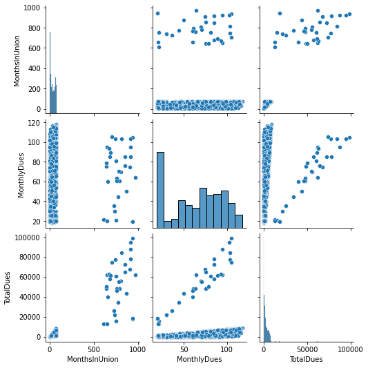

```python
sns.pairplot(x_num)
```

The plot on the bottom left suggests collinearity.

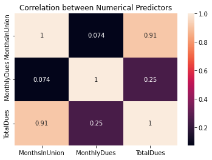

```python
plt.figure()
sns.heatmap(x_num.corr(),annot=True)
plt.title('Correlation between Numerical Predictors')
```

As we might expect, the number of months an individual is in the union is strongly correlated to the total amount of dues they have paid. These two predictors have a correlation coefficient of 0.91.

A good model would only make predictions using one of these two features. I will choose to drop 'TotalDues'.

##### Distribution and Outliers

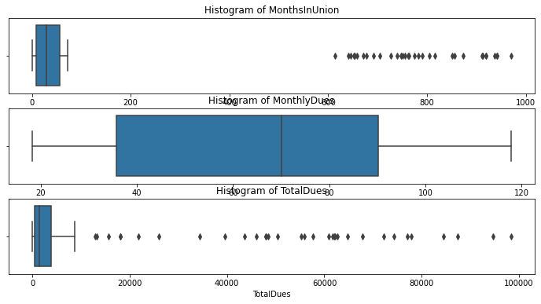

```python
plt.figure(figsize=[12,6])
for i in range(0,len(x_num.columns)):
    plt.subplot(len(x_num.columns),1,i+1)
    sns.boxplot(x=x_num.iloc[:,i])
    plt.title(f'Histogram of {x_num.columns[i]}')
plt.show()
```

These boxplots demonstrate the presence of outliers in the data. Since I am using 'MonthsInUnion' over 'TotalDues' I will look to drop the outliers there.

```python
#check descriptive statistics
df['MonthsInUnion'].describe()
```

```
count    1995.000000
mean       44.826065
std        99.774592
min         1.000000
25%         9.000000
50%        29.000000
75%        57.000000
max       970.000000
Name: MonthsInUnion, dtype: float64
```

```python
#view number of outlier rows
outliers_months = np.where(df['MonthsInUnion'] > 100)
print(outliers_months)
len(outliers_months[0])
```

```
(array([  30,   33,  115,  183,  308,  316,  355,  411,  412,  431,  455,
        568,  582,  650,  710,  712,  759,  788,  877,  902,  995, 1137,
       1212, 1223, 1227, 1400, 1470, 1535, 1557, 1587, 1688, 1838, 1878],
      dtype=int64),)
```

```
33
```

33 individuals have outlier values for 'Months in Union'. In fact the highest observation is 970 months, which is equal to almost 81 years in the union!

From the boxplot, the outlier cluster is very far from the rest of the observations. In order to create a model that can effectively generalize the usual case, I would strongly consider dropping these outliers.

```python
#check outlier rows against target variable
outlier_indices = np.where(df['MonthsInUnion'] > 200)
outliers = df.iloc[outlier_indices].loc[:,['MonthsInUnion','LeftUnion']]
outliers
```

|  | MonthsInUnion | LeftUnion |
| --- | --- | --- |
| 30 | 970 | No |
| 33 | 613 | No |
| 115 | 791 | No |
| 183 | 751 | Yes |
| 309 | 678 | No |
| 317 | 747 | No |
| 356 | 761 | No |
| 412 | 756 | No |
| 413 | 763 | Yes |
| 432 | 645 | Yes |
| 456 | 726 | No |
| 569 | 816 | No |
| 583 | 920 | No |
| 651 | 873 | No |
| 711 | 911 | Yes |
| 713 | 652 | No |
| 760 | 942 | No |
| 789 | 654 | No |
| 878 | 641 | No |
| 903 | 913 | No |
| 996 | 804 | No |
| 1138 | 671 | No |
| 1214 | 851 | No |
| 1225 | 691 | No |
| 1229 | 659 | No |
| 1402 | 739 | No |
| 1473 | 855 | Yes |
| 1538 | 937 | No |
| 1560 | 774 | No |
| 1590 | 782 | Yes |
| 1692 | 920 | Yes |
| 1842 | 941 | No |
| 1882 | 705 | No |

```python
#What proportion of these outliers left the union?
outliers['LeftUnion'].value_counts()
```

```
No     26
Yes     7
Name: LeftUnion, dtype: int64
```

```python
#In contrast, what proportion of the data left the union?
df['LeftUnion'].value_counts()
```

```
No     1495
Yes     500
Name: LeftUnion, dtype: int64
```

```python
df_clean = df.drop(outliers_months[0])
```

```python
df_clean.shape
#rows dropped: 33 outliers, 4 rows of missing values
#1999 - 37 = 1962 (good)
```

```
(1962, 21)
```

```python
# Re-split cleaned Dataframe
y_clean = df_clean.loc[:,'LeftUnion']
X_num_clean = df_clean.loc[:,['MonthsInUnion','MonthlyDues']] #dropped total dues
X_cat_clean = df_clean.loc[:,['gender','Management','USAcitizen','Married','ContinuingEd','StateOfResidence','Connectivity','FeatureA',
        'FeatureB','FeatureC','FeatureD','FeatureE','FeatureF','DuesFrequency','PaperlessBilling','PaymentMethod']]
```

### Categorical Variables

```python
X_cat_clean.columns
#all nominal
```

```
Index(['gender', 'Management', 'USAcitizen', 'Married', 'ContinuingEd',
       'StateOfResidence', 'Connectivity', 'FeatureA', 'FeatureB', 'FeatureC',
       'FeatureD', 'FeatureE', 'FeatureF', 'DuesFrequency', 'PaperlessBilling',
       'PaymentMethod'],
      dtype='object')
```

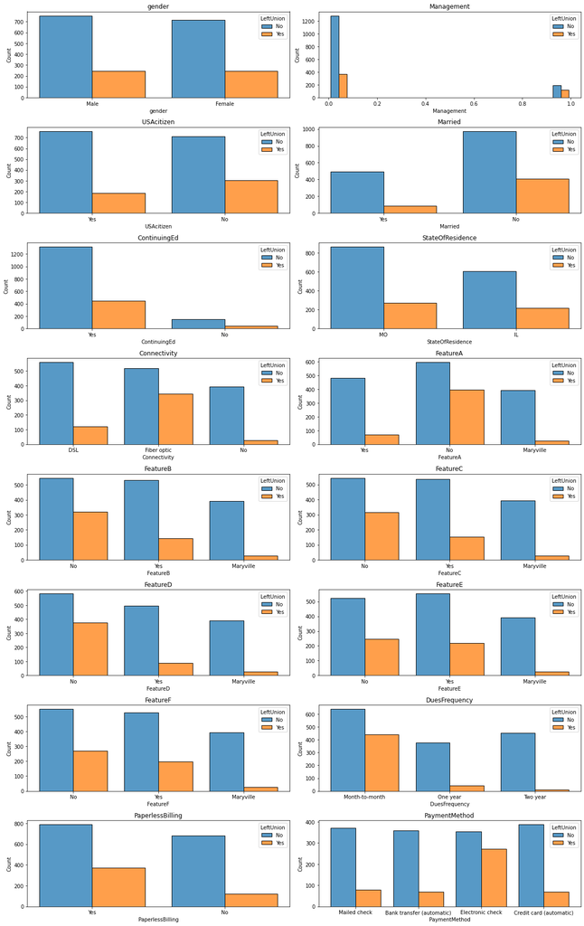

```python
#Bivariate plot for each categorical variable vs target variable
#we want plot for each categorical variable against target variable (yes or no)

plt.figure(figsize=[16,50])
for i in range(0,len(X_cat_clean.columns)):
    plt.subplot(len(X_cat_clean.columns),2,i+1)
    sns.histplot(x=X_cat_clean.iloc[:,i],multiple="dodge",hue=y_clean,shrink=0.8)
    plt.title(X_cat_clean.columns[i])
plt.tight_layout()
plt.show()
```

```python
np.unique(df_clean['FeatureE'])
#what is "Maryville" response in this feature? may consider dropping
```

```
array(['Maryville', 'No', 'Yes'], dtype=object)
```

### Preprocess variables

- Normalize quanitative variables
- One-hot Encoding for categorical variables
- Convert no/yes of target to 0/1

```python
X_num_normalized = normalize(X_num_clean)
X_num_normalized
```

```
array([[0.25186977, 0.96776114],
       [0.04592849, 0.99894473],
       [0.54100614, 0.84101864],
       ...,
       [0.30280894, 0.95305128],
       [0.44945948, 0.89330072],
       [0.58279006, 0.81262276]])
```

```python
#One hot encoding
union_encoder = OneHotEncoder(sparse_output=False)
union_encoder.fit(X_cat_clean)
X_enc = union_encoder.transform(X_cat_clean)
print(f'Shape of encoded categorial variables: {X_enc.shape}')
```

```
Shape of encoded categorial variables: (1962, 42)
```

```python
len(df_clean)
```

```
1962
```

```python
#combine numerical and categorical
X = np.hstack((X_num_normalized,X_enc))
print(f'Shape of cleaned and preprocessed features: {X.shape}')
```

```
Shape of cleaned and preprocessed features: (1962, 44)
```

### Split Data into training, validation, test sets

```python
X_train, X_hold, y_train, y_hold = train_test_split(X, y_clean ,test_size=0.3, stratify=y_clean, random_state=1)
X_valid, X_test, y_valid, y_test = train_test_split(X_hold, y_hold ,test_size=0.5, stratify=y_hold, random_state=1)

print(f'Training Set Shape:   {X_train.shape}')
print(f'Validation Set Shape: {X_valid.shape}')
print(f'Test Set Shape:       {X_test.shape}')
```

```
Training Set Shape:   (1373, 44)
Validation Set Shape: (294, 44)
Test Set Shape:       (295, 44)
```

# ---- Create preliminary models ----

### Model 1: Logistic Regression

```python
lr_mod = LogisticRegression(solver='lbfgs', max_iter=1000,multi_class='multinomial',penalty=None)
lr_mod.fit(X_train, y_train)

print(f'Training Accuracy:   {lr_mod.score(X_train, y_train)}')
print(f'Validation Accuracy: {lr_mod.score(X_valid, y_valid)}')
```

```
Training Accuracy:   0.820830298616169
Validation Accuracy: 0.8197278911564626
```

### Model 2: Decision Tree

```python
#Hyperparameter selection
dt_train_acc = []
dt_valid_acc = []

depth_range = range(2,30)

for d in depth_range:
    np.random.seed(1)
    temp_tree = DecisionTreeClassifier(max_depth=d)
    temp_tree.fit(X_train, y_train)
    dt_train_acc.append(temp_tree.score(X_train,y_train))
    dt_valid_acc.append(temp_tree.score(X_valid,y_valid))

dt_idx = np.argmax(dt_valid_acc)
dt_opt_depth = depth_range[dt_idx]
opt_dt_train_acc = dt_train_acc[dt_idx]
opt_dr_valid_acc = dt_valid_acc[dt_idx]

print(f'Optimal value for max_depth:           {dt_opt_depth}')
print(f'Training Accuracy for Optimal Model:   {opt_dt_train_acc:.4f}')
print(f'Validation Accuracy for Optimal Model: {opt_dr_valid_acc:.4f}')
```

```
Optimal value for max_depth:           2
Training Accuracy for Optimal Model:   0.8157
Validation Accuracy for Optimal Model: 0.8095
```

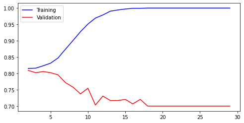

```python
plt.figure(figsize=[8,4])
plt.plot(depth_range, dt_train_acc, color='blue', label='Training')
plt.plot(depth_range, dt_valid_acc, color='red', label='Validation' )
plt.legend()
plt.show()
```

### Model 3: Random Forest

```python
rf_train_acc = []
rf_valid_acc = []

for d in depth_range:
    np.random.seed(1)
    temp_forest = RandomForestClassifier(max_depth=d, n_estimators=100)
    temp_forest.fit(X_train, y_train)
    rf_train_acc.append(temp_forest.score(X_train,y_train))
    rf_valid_acc.append(temp_forest.score(X_valid,y_valid))

rf_idx = np.argmax(rf_valid_acc)
rf_opt_depth = depth_range[rf_idx]
opt_rf_train_acc = rf_train_acc[rf_idx]
opt_rf_valid_acc = rf_valid_acc[rf_idx]

print(f'Optimal value for max_depth:           {rf_opt_depth}')
print(f'Training Accuracy for Optimal Model:   {opt_rf_train_acc:.4f}')
print(f'Validation Accuracy for Optimal Model: {opt_rf_valid_acc:.4f}')
```

```
Optimal value for max_depth:           15
Training Accuracy for Optimal Model:   0.9985
Validation Accuracy for Optimal Model: 0.8197
```

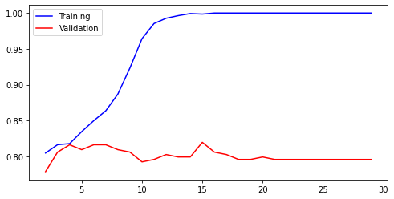

```python
plt.figure(figsize=[8,4])
plt.plot(depth_range, rf_train_acc, color='blue',label='Training')
plt.plot(depth_range, rf_valid_acc, color='red', label='Validation')
plt.legend()
plt.show()
```

### Model 4: Neural Network Model

```python
union_NN = MLPClassifier(max_iter=1000)
union_NN.fit(X_train, y_train)
```

```
MLPClassifier(max_iter=1000)
```

```python
print(f'Training Accuracy for NeuralNet:   {union_NN.score(X_train,y_train):.4f}')
print(f'Validation Accuracy for Neuralnet: {union_NN.score(X_valid,y_valid):.4f}')
```

```
Training Accuracy for NeuralNet:   0.9731
Validation Accuracy for Neuralnet: 0.7415
```

### Model 5: Support Vector Classifier Model

```python
svc_model = SVC()
svc_model.fit(X_train,y_train)

svm_preds = svc_model.predict(X_valid)
```

```python
print(confusion_matrix(y_valid,svm_preds))
```

```
[[202  19]
 [ 46  27]]
```

```python
print(classification_report(y_valid,svm_preds))
```

```
              precision    recall  f1-score   support

          No       0.81      0.91      0.86       221
         Yes       0.59      0.37      0.45        73

    accuracy                           0.78       294
   macro avg       0.70      0.64      0.66       294
weighted avg       0.76      0.78      0.76       294
```

Similar range to the other preliminary models for validation set performance, 0.78.

# Overview of Preliminary Models:

- Only ~75-80% accuracy on the validation set which is not very good.
- How this be improved?

One strategy to combat overfitting is to **reduce model complexity** so that it can effectively generalize to new data

- Explore options for feature selection and feature engineering
- regularize linear model
- tune hyperparameters for other models

# Feature Selection & Reprocessing

#### Which features were already chosen to be left out?

- For numeric features, 'MonthsInUnion' and 'TotalDues' were collinear. This was determined by computing their correlation coefficient, in addition to simply viewing their pairplot to be linear. As expected, the more time someone is in the union, the higher their total dues.

#### Which categorical features are irrelevant?

features that have little to no difference on the yes/no distribution regardless of variable response.

Features with the same distribution as each other, they represent the same thing

- Feature B, C, D, E, F have similar distributions, so I will only keep feature F

Overall the list of categorical features has been reduced by 8 compared to the previous set of models.

Reducing the number of features is a good strategy to prevent overfitting (as shown with the training data performance being notably higher than the validation set performance), in addition to having the model train on the feature that most directly contribute to predicting the target variable rather than noise.

#### Is this dataset a good candidate for PCA?

- Overall the dataset does not contain many training examples or features.
- PCA results in a loss of information and explanability for the model. I would instead first bet on the more manual approach to feature selection seen above as it maintains the explanability of the model while still having a workable number of features.
- As a result, PCA seems better suited as a future consideration or alternate approach if the model tuning calls for it.

```python
# Reselect and re-preprocess the new categorical variable selection

X_catselect = df_clean.loc[:,['Management','Married','Connectivity','FeatureA',
                              'FeatureF','DuesFrequency','PaperlessBilling','PaymentMethod']]

#One-hot encode the new categorical variable selection

select_encoder = OneHotEncoder(sparse_output=False)
select_encoder.fit(X_catselect)
X_encselect = select_encoder.transform(X_catselect)

print(f'Shape of encoded categorial variable selection: {X_encselect.shape}')
```

```
Shape of encoded categorial variable selection: (1962, 22)
```

The selected categorical features have dimension 22 instead of 42 from using all of them. This should hopefully result in some improvement in regards to overfitting.

```python
#Re-split data with new selection

#combine numerical and categorical
X_sel = np.hstack((X_num_normalized,X_encselect))

#export cleaned, normalized, encoded data as csv
df_clean = pd.DataFrame(X_sel)
df_clean.to_csv('cleaned_union_project_data_Calvin_Tran.csv')

print(f'Shape of selected features: {X_sel.shape}')

X_train, X_hold, y_train, y_hold = train_test_split(X_sel, y_clean ,test_size=0.2, stratify=y_clean, random_state=1)
X_valid, X_test, y_valid, y_test = train_test_split(X_hold, y_hold ,test_size=0.5, stratify=y_hold, random_state=1)

print(f'Training Set Shape:   {X_train.shape}')
print(f'Validation Set Shape: {X_valid.shape}')
print(f'Test Set Shape:       {X_test.shape}')
```

```
Shape of selected features: (1962, 24)
Training Set Shape:   (1569, 24)
Validation Set Shape: (196, 24)
Test Set Shape:       (197, 24)
```

# Models, Round 2

### LR model 2

```python
lr_mod = LogisticRegression(solver='lbfgs', max_iter=1000,multi_class='multinomial',penalty=None)
lr_mod.fit(X_train, y_train)

print(f'Training Accuracy:   {lr_mod.score(X_train, y_train)}')
print(f'Validation Accuracy: {lr_mod.score(X_valid, y_valid)}')
```

```
Training Accuracy:   0.8138942001274697
Validation Accuracy: 0.8367346938775511
```

```python
#Hyperparameter selection
dt_train_acc = []
dt_valid_acc = []

depth_range = range(2,30)

for d in depth_range:
    np.random.seed(1)
    temp_tree = DecisionTreeClassifier(max_depth=d)
    temp_tree.fit(X_train, y_train)
    dt_train_acc.append(temp_tree.score(X_train,y_train))
    dt_valid_acc.append(temp_tree.score(X_valid,y_valid))

dt_idx = np.argmax(dt_valid_acc)
dt_opt_depth = depth_range[dt_idx]
opt_dt_train_acc = dt_train_acc[dt_idx]
opt_dr_valid_acc = dt_valid_acc[dt_idx]

print(f'Optimal value for max_depth:           {dt_opt_depth}')
print(f'Training Accuracy for Optimal Model:   {opt_dt_train_acc:.4f}')
print(f'Validation Accuracy for Optimal Model: {opt_dr_valid_acc:.4f}')
```

```
Optimal value for max_depth:           2
Training Accuracy for Optimal Model:   0.8139
Validation Accuracy for Optimal Model: 0.8214
```

```python
rf_train_acc = []
rf_valid_acc = []

for d in depth_range:
    np.random.seed(1)
    temp_forest = RandomForestClassifier(max_depth=d, n_estimators=100)
    temp_forest.fit(X_train, y_train)
    rf_train_acc.append(temp_forest.score(X_train,y_train))
    rf_valid_acc.append(temp_forest.score(X_valid,y_valid))

rf_idx = np.argmax(rf_valid_acc)
rf_opt_depth = depth_range[rf_idx]
opt_rf_train_acc = rf_train_acc[rf_idx]
opt_rf_valid_acc = rf_valid_acc[rf_idx]

print(f'Optimal value for max_depth:           {rf_opt_depth}')
print(f'Training Accuracy for Optimal Model:   {opt_rf_train_acc:.4f}')
print(f'Validation Accuracy for Optimal Model: {opt_rf_valid_acc:.4f}')
```

```
Optimal value for max_depth:           6
Training Accuracy for Optimal Model:   0.8337
Validation Accuracy for Optimal Model: 0.8316
```

```python
union_NN = MLPClassifier(max_iter=1000)
union_NN.fit(X_train, y_train)
print(f'Training Accuracy for NeuralNet:   {union_NN.score(X_train,y_train):.4f}')
print(f'Validation Accuracy for Neuralnet: {union_NN.score(X_valid,y_valid):.4f}')
```

```
Training Accuracy for NeuralNet:   0.8547
Validation Accuracy for Neuralnet: 0.7347
```

```python
svc_model = SVC()
svc_model.fit(X_train,y_train)

svm_preds = svc_model.predict(X_valid)
```

```python
print(confusion_matrix(y_valid,svm_preds))
```

```
[[134  13]
 [ 26  23]]
```

```python
print(classification_report(y_valid,svm_preds))
```

```
              precision    recall  f1-score   support

          No       0.84      0.91      0.87       147
         Yes       0.64      0.47      0.54        49

    accuracy                           0.80       196
   macro avg       0.74      0.69      0.71       196
weighted avg       0.79      0.80      0.79       196
```

> The validation accuracy for the SVM Classifier is 0.80.

## Model Write-up & Comments on model selection

As mentioned above, this is a binary classification type problem. A lot of popular models exist for this type of problem:

- Logistic Regression: Sigmoidal classifier that is good for a problem like this one where there are only 2 classes.
- Decision Trees: Uses features for attribute tests that determine the final output.
- Random Forests: Similar to decision trees but ensemble model that is more robust
- Neural Networks: Transforms inputs with weights and activation functions for output.
- Support Vector Machine: Classifier that finds the optimal decision boundary between the two classes.

Since these *all* work for binary classification problems, and they all have sklearn implementations, I will choose to implement all five of these.

With the cross-validation set that was split earlier, these models can be compared and the one with highest performance selected to be run on the test set.

### Accuracy comparison (from second round of models):

```python
print(f'Logistic Regression Validation Accuracy:    {lr_mod.score(X_valid, y_valid):.4f}')
print(f'Decision Tree Validation Accuracy:          {opt_dr_valid_acc:.4f}')
print(f'Random Forest Validation Accuracy:          {opt_rf_valid_acc:.4f}')
print(f'Neuralnet Validation Accuracy:              {union_NN.score(X_valid,y_valid):.4f}')
print(f'Support Vector Machine Validation Accuracy: {classification_report(y_valid,svm_preds,output_dict=True)["accuracy"]:.4f}')
```

```
Logistic Regression Validation Accuracy:    0.8367
Decision Tree Validation Accuracy:          0.8214
Random Forest Validation Accuracy:          0.8316
Neuralnet Validation Accuracy:              0.7347
Support Vector Machine Validation Accuracy: 0.8010
```

For these models it seems the simplest model (Logistic Regression) had the best performance among them. For a binary classification problem I think this is fine.

```python
print(f'Logistic Regression Test Accuracy:    {lr_mod.score(X_train, y_train):.4f}')
print(f'Decision Tree Test Accuracy:          {opt_dt_train_acc:.4f}')
print(f'Random Forest Test Accuracy:          {opt_rf_train_acc:.4f}')
print(f'Neuralnet Test Accuracy:              {union_NN.score(X_train,y_train):.4f}')
```

```
Logistic Regression Test Accuracy:    0.8139
Decision Tree Test Accuracy:          0.8139
Random Forest Test Accuracy:          0.8337
Neuralnet Test Accuracy:              0.8547
```

Likewise the logistic regression model is less prone to overfitting the data than other models. In the first round of models, the neural network fit the training set with an accuracy of 0.9731 which was significantly overfitting compared to the validation performance.

# Overview on second round of models, summary of results and next steps

These models are now underfitting the training data compared to the first set of models. However their performance on the validation set is relatively unchanged.

One strategy is to try some feature engineering with the features that were kept. Since the model is not overfitting, if performance on the training set goes up, the validation set should follow.

Changes can be easily verified by simple logistic regression.

Recall that earlier I checked "what proportion of the data left the union?"

```python
df['LeftUnion'].value_counts()
```

```
No     1495
Yes     500
Name: LeftUnion, dtype: int64
```

A baseline model that assumes nobody ever leaves the union (ie. doesn't do anything put output 0) itself has a performance of 1495/1995, or 0.749.

For 3 of the models, model performance on the validation set was around 0.83. The provided features of course provide a better prediction than simply guessing "no" for each individual.

What cutoff seems appropriate as good enough? As mentioned above I do think there is a little more that can be done in terms of feature engineering to try and coax out a little better performance.

However, it could very well be that the provided features are simply not enough to provide better predictions. Broadly, the dataset only has features for basic demographics and union payments.

Ideally more informative features would have included things such as:

- Previous union engagement
- Some metric of job satisfaction
- Job position beyond management/non-management

In particular these features seem really ripe for binning the data and that may lead to better performance.

## Test set performance for best model

The model from round two with the best validation performance was the Logistic Regression model with 0.8367.

```python
print(f'Training Accuracy:   {lr_mod.score(X_train, y_train)}')
print(f'Validation Accuracy: {lr_mod.score(X_valid, y_valid)}')
```

```
Training Accuracy:   0.8138942001274697
Validation Accuracy: 0.8367346938775511
```

```python
print(f'Test Accuracy: {lr_mod.score(X_test, y_test)}')
```

```
Test Accuracy: 0.817258883248731
```

## Example of next step given more time: Investigate model using only numeric and then only categorical features

```python
#test, what if we make a model using only the numerical features? Only the categorical ones?
X_sel[0:2] #numeric features
X_sel[3:] #categorcal features
```

```
array([[0.66571954, 0.74620205, 1.        , ..., 0.        , 0.        ,
        1.        ],
       [0.33437436, 0.94244034, 1.        , ..., 0.        , 1.        ,
        0.        ],
       [0.15526489, 0.98787287, 1.        , ..., 0.        , 0.        ,
        1.        ],
       ...,
       [0.30280894, 0.95305128, 1.        , ..., 0.        , 0.        ,
        1.        ],
       [0.44945948, 0.89330072, 1.        , ..., 0.        , 1.        ,
        0.        ],
       [0.58279006, 0.81262276, 1.        , ..., 0.        , 1.        ,
        0.        ]])
```

### Numeric features only

```python
X_train, X_hold, y_train, y_hold = train_test_split(X_num_normalized, y_clean ,test_size=0.2, stratify=y_clean, random_state=1)
X_valid, X_test, y_valid, y_test = train_test_split(X_hold, y_hold, test_size=0.5, stratify=y_hold, random_state=1)

print(f'Training Set Shape:   {X_train.shape}')
print(f'Shape of Training labels: {y_train.shape}')
print(f'Validation Set Shape: {X_valid.shape}')
print(f'Test Set Shape:       {X_test.shape}')

lr_modTEST = LogisticRegression(solver='lbfgs', max_iter=1000,multi_class='multinomial',penalty=None)
lr_modTEST.fit(X_train, y_train)

print('')
print(f'Training Accuracy:   {lr_modTEST.score(X_train, y_train)}')
print(f'Validation Accuracy: {lr_modTEST.score(X_valid, y_valid)}')
```

```
Training Set Shape:   (1569, 2)
Shape of Training labels: (1569,)
Validation Set Shape: (196, 2)
Test Set Shape:       (197, 2)

Training Accuracy:   0.780114722753346
Validation Accuracy: 0.8214285714285714
```

These results are actually pretty close to what our model with all the features is already outputting.

### Categorical Features only

```python
X_train, X_hold, y_train, y_hold = train_test_split(X_encselect, y_clean,test_size=0.2, stratify=y_clean, random_state=1)
X_valid, X_test, y_valid, y_test = train_test_split(X_hold, y_hold, test_size=0.5, stratify=y_hold, random_state=1)

print(f'Training Set Shape:   {X_train.shape}')
print(f'Shape of Training labels: {y_train.shape}')
print(f'Validation Set Shape: {X_valid.shape}')
print(f'Test Set Shape:       {X_test.shape}')

lr_modTEST = LogisticRegression(solver='lbfgs', max_iter=1000,multi_class='multinomial',penalty=None)
lr_modTEST.fit(X_train, y_train)

print('')
print(f'Training Accuracy:   {lr_modTEST.score(X_train, y_train)}')
print(f'Validation Accuracy: {lr_modTEST.score(X_valid, y_valid)}')
```

```
Training Set Shape:   (1569, 22)
Shape of Training labels: (1569,)
Validation Set Shape: (196, 22)
Test Set Shape:       (197, 22)

Training Accuracy:   0.7960484384958573
Validation Accuracy: 0.7653061224489796
```

These results are pretty bad and only marginally better than a model that only predicts "0" and nothing else.

These two steps suggest that a good next step would be to work with the categorical features some more to see if they can become more informative.